# Medidas de tendencia central

Estadística 2022-2, [Facultad de economía](http://www.economia.unam.mx/)

2/3/2022

### 1. ¿Qué son las medidas de tendencia central? 🤔

Para este ejemplo, primero generaremos una serie de **100** números aleatorios entre **1** y **20** mediante la función `sample`. El argumento `TRUE` nos permitirá generar una muestra con remplazo:

```r
numeros <- sample(1:20, 100, TRUE)
numeros
```

```
##   [1]  8 14  1  5 14 14 18 15  4 14  9  1  4  8  5  3 11 10  1  5  6  2 20 18 14
##  [26]  2 11 17 12 10  3 20 15 19 16 15 19 18  3 14 12 20 10 18  5 16 11 12  3  2
##  [51] 18 17 19 19  6  5  2 13  5 16  5 20 14  3  7  1 14 10 10  1 10 19 11  8 16
##  [76] 13 11 13  9 15 12 17 16 14  8  9 18 19 10  3 11 20 14  8 13  4  6  7 13  8
```

### 2. Mediana 📍

Para obtener la **mediana**, podemos ordenar los `numeros` de menor a mayor, **el número que esté en medio de la muestra será la mediana**. Si utilizamos R, se puede hacer el cálculo de la **mediana** con la función `median`:

```r
mediana <- median(numeros)
mediana
```

```
## [1] 11
```

### 3. Media 🧮

$$Media ={\frac {1}{n}}\sum _{i=1}^{n}a_{i}={\frac {a_{1}+a_{2}+\cdots +a_{n}}{n}}$$

Si usamos R, podemos obtener la media de una muestra si utlilizamos la función **mean**:

```r
media <- mean(numeros)
media
```

```
## [1] 10.87
```

### 4. Moda 📊

Podemos saber cuál es la **frecuencia** (número de veces que aparece un elemento en una muestra) de cada número si dibujamos un **histograma** con la función `hist`, **aquel elemento con mayor frecuencia será la moda**:

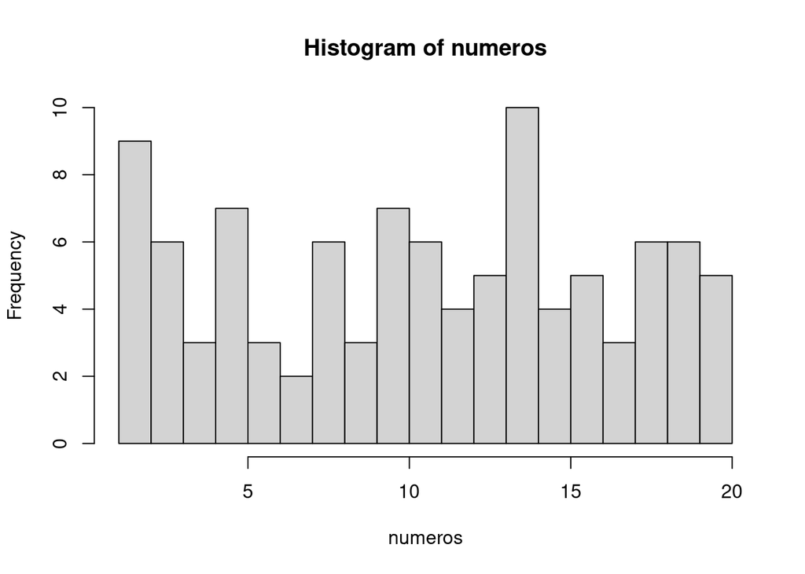

```r
# El argumento breaks nos permite dividir en histograma en las partes que queramos
hist(numeros, breaks = 20)
```

Para obtener un resultado con más precisión, podemos obtener la **moda** si generamos una **tabla de frecuencias** con la función `table` y la función `data.frame`, **aquel elemento con mayor frecuencia será la moda**:

```r
tabla.frecuencias <- data.frame(table(numeros))
tabla.frecuencias
```

```
##    numeros Freq
## 1        1    5
## 2        2    4
## 3        3    6
## 4        4    3
## 5        5    7
## 6        6    3
## 7        7    2
## 8        8    6
## 9        9    3
## 10      10    7
## 11      11    6
## 12      12    4
## 13      13    5
## 14      14   10
## 15      15    4
## 16      16    5
## 17      17    3
## 18      18    6
## 19      19    6
## 20      20    5
```

### 5. Ejercicio 👩‍💻👨‍💻✍

Aplica lo que aprendiste, obten la **mediana**, **media** y **moda** de la siguiente muestra de números:

```r
# Con la función seq, creamos una secuencia de 1 a 10 en intervalos de 0.1 en 0.1
secuencia <- seq(1, 10, 0.1)
muestra <- sample(secuencia, 100, TRUE)
muestra
```

```
##   [1]  5.6  4.3  3.3  8.7  1.7  2.0  1.5  7.8  7.0  7.6  8.2  2.5  2.7  7.6  5.7
##  [16]  6.1  4.1  8.4 10.0  7.6  4.1  9.6  8.6  8.1  3.5  6.3  3.7  6.4  4.3  1.8
##  [31]  3.9  5.6  8.8  2.2  5.9  8.6  6.0  1.2  3.6  1.4  4.0  8.2  6.3  5.2  5.6
##  [46]  2.2  4.2  7.8  8.7  9.9  6.0  7.5  4.7  9.5  3.3  8.2  9.7  9.3  3.8  6.3
##  [61]  3.7  5.9  3.5  7.1  7.1  1.0  2.6  9.5  8.3  3.7  1.8  7.6  2.9  5.1  3.2
##  [76]  5.9  1.5  3.4  7.1  8.2  1.7  4.2  9.5  8.3  2.5  3.8  3.8  3.1  2.8  5.6
##  [91]  4.0  7.9  9.4  9.7  8.9  7.9  7.3  8.1  5.9  8.4
```

##### Mediana

```r
# Aquí el cálculo de la mediana
```

##### Media

```r
# Aquí el cálculo de la media
```

##### Moda

```r
# Aquí el cálculo de la moda
```

💻[Código disponible en RStudio Cloud](https://rstudio.cloud/project/3671022)💻